## STATS 763: Assignment 4: Don’t feed the crocodiles

#### 07/10/2024

The file `bitey.txt` contains information on size, jaw shape, bite force, and tooth pressure for all currently existing species of crocodilians (crocodiles, alligators, and closely related reptiles).

In these variable names, the “molariform” teeth are at the back of the jaw where food is chewed and the “caniniform” teeth at the front of the jaw where food is initially seized. The ‘rostrum’ is the snout.

### Data Manipulation

```r
crocs <- read.table("data/bitey.txt", header=TRUE, fill=TRUE)
# remove observations with missing species
crocs <- crocs[!(crocs$Species == "" | crocs$Species == "-"), ]
# split all cols with ranges to lower and upper
crocs <- split_ranges_automatically(crocs)
# convert em-dashes to NA
crocs <- crocs %>%
  mutate(across(everything(), ~na_if(as.character(.), "—")))
# convert everything to numeric
crocs <- crocs %>%
  mutate(across(everything(), ~as.numeric(.)))
```

### 1) What are the relationships between the size of the crocodilian and the bite force?

We assume the size is represented by the mean total length `MTL`. We take the mean of measured covariates rather than upper or lower of ranges.

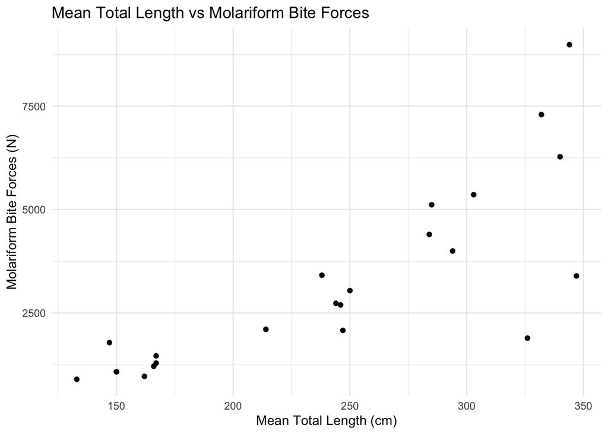

Increasing mean total length `MTL` of the crocodile appears to increase the molariform bite forces `MBF`.

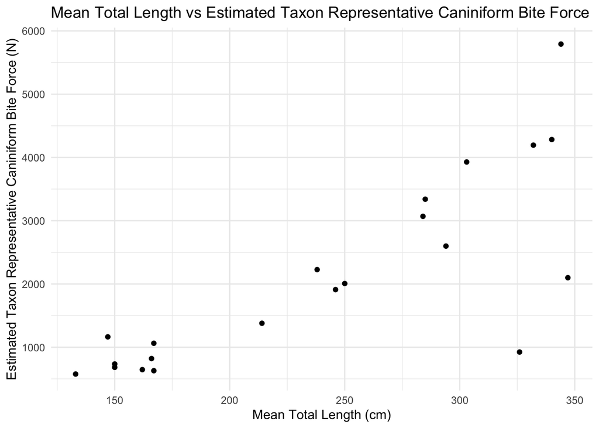

The estimated taxon representative caniniform bite force, `CBF`, is lower on average than the molariform bite force. The `CBF` is estimated from the molariform bite force, hence correlated.

### 2) What are the relationships between the size of the crocodilian and the tooth pressure?

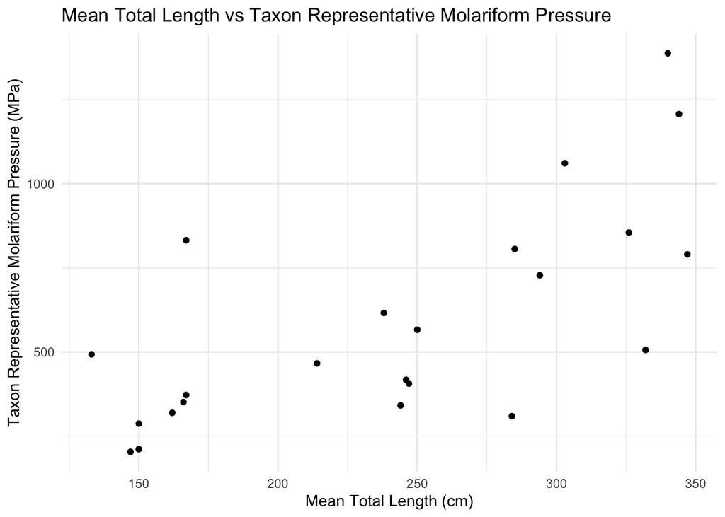

Similarly, increasing mean total length `MTL` of the crocodile appears to increase the Taxon Representative Molariform Pressure `MP`.

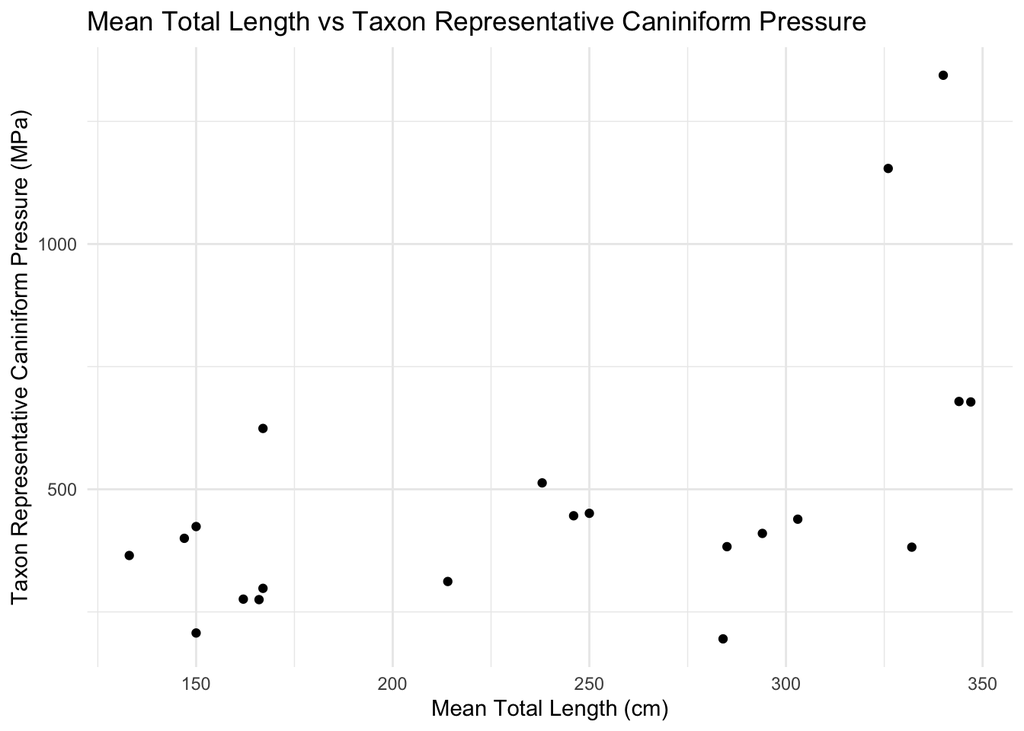

### 3) Fit a model to predict bite force from the size, shape, and mass measurements.

Since the caniniform bite force is bite principally from the molariform bite force, we predict the molariform bite force only.

We first try a linear model as the molariform bite force can be a range of positive real numbers.

I didn’t use any ratios as they can be misleading variables.

```r
bite_model_unweighted <- lm(MBF ~ MTL + MBM + MCA, data = crocs)
summary(bite_model_unweighted)
```

```
##
## Call:
## lm(formula = MBF ~ MTL + MBM + MCA, data = crocs)
##
## Residuals:
##     Min      1Q  Median      3Q     Max
## -963.51 -240.54  -57.39  216.73  948.28
##
## Coefficients:
##             Estimate Std. Error t value Pr(>|t|)
## (Intercept) 1880.461    562.879   3.341  0.00343 **
## MTL          -11.005      3.251  -3.385  0.00311 **
## MBM           37.930      3.452  10.989 1.13e-09 ***
## MCA          106.587     33.525   3.179  0.00494 **
## ---
## Signif. codes:  0 '***' 0.001 '**' 0.01 '*' 0.05 '.' 0.1 ' ' 1
##
## Residual standard error: 456.7 on 19 degrees of freedom
## Multiple R-squared:  0.9628, Adjusted R-squared:  0.9569
## F-statistic:   164 on 3 and 19 DF,  p-value: 9.315e-14
```

```r
sample_weights <- as.numeric(crocs$N)
bite_model_weighted <- lm(MBF ~ MTL + MBM + MCA, weights = sample_weights, data = crocs)
summary(bite_model_weighted)
```

```
##
## Call:
## lm(formula = MBF ~ MTL + MBM + MCA, data = crocs, weights = sample_weights)
##
## Weighted Residuals:
##     Min      1Q  Median      3Q     Max
## -1492.9  -424.5  -272.3   372.0  1526.5
##
## Coefficients:
##             Estimate Std. Error t value Pr(>|t|)
## (Intercept) 1583.675    517.296   3.061  0.00642 **
## MTL           -9.423      2.914  -3.234  0.00437 **
## MBM           36.324      2.809  12.930 7.27e-11 ***
## MCA          124.310     40.380   3.079  0.00618 **
## ---
## Signif. codes:  0 '***' 0.001 '**' 0.01 '*' 0.05 '.' 0.1 ' ' 1
##
## Residual standard error: 751.4 on 19 degrees of freedom
## Multiple R-squared:  0.9772, Adjusted R-squared:  0.9736
## F-statistic: 271.1 on 3 and 19 DF,  p-value: 9.09e-16
```

### 4) The largest and smallest crocodilians in the fossil record have total length and estimated mass (0.8m, 2.6kg: Procaimanoidea kayi, Alligatoridea) and (11m, 4600kg: Deinosuchus riograndensis, Alligatoridea). Estimate their bite force.

We can only use a model with length and mass as covariates as these are the only provided covariates for the new data.

```r
bite_prediction_model_weighted <- lm(MBF ~ MTL + MBM, weights = sample_weights, data = crocs)

smallest_largest <- data.frame(
  MTL = c(0.8, 11),
  MBM = c(2.6, 4600)
)

bite_predictions <- predict(bite_prediction_model_weighted, newdata = smallest_largest, interval = "prediction", level = 0.95)
```

```
## Warning in predict.lm(bite_prediction_model_weighted, newdata = smallest_largest, : Assuming constant prediction variance even though model fit is weighted
```

```r
bite_predictions
```

```
##          fit          lwr        upr
## 1   2302.564     84.50779   4520.621
## 2 180102.086 148226.39963 211977.773
```

THERE ARE WARNINGS: “Warning: Assuming constant prediction variance even though model fit is weighted”

Note these crocodilians are the largest and smallest in the fossil record, therefore will be on the extreme ends of our model. We might not have appropriate predictive support for predicting their bite forces, but the prediction interval should account for that.

We could potentially use data from other crocodile families for building the model for prediction.